# Chap15

202140191 엄태훈

2021-04-30(Fri)

# Chap6 One-Way Analysis of Variance

앞서, 우리는 집단 간의 차이를 알아보고자 할 때 T-test 방법을 사용하였다.  
하지만 비교하고자 하는 집단의 수가 2 개의 집단이 아니라 3개, 4개 등 3집단 이상일 경우 t-test는 사용할 수 없다.

이렇게 집단이 3개 이상일 때 집단간의 평균의 차이를 알아보기위해 사용하는 방법이 바로 *ANOVA*방법이다.  
*ANOVA*는 Analysis Of Variance의 약자로 분산분석이라고 일컫는다.

One-way ANOVA는 분산분석에서 사용되는 독립변수의 갯수가 하나일때를 말한다.  
Two-way ANOVA는 분산분석에서 사용되는 독립변수의 갯수가 두 개 일때를 말한다.

분산분석의 귀무가설은 다음과 같다.

H0: 모든 집단의 평균은 같다.  
H1: 적어도 한 집단의 평균은 다르다.

R에서 분산분석을 실행하는 함수는 aov와 anova 함수가 있다.  
aov의 경우, (종속변수 ~ 독립변수) Formula의 형태로 지정을 해줘야 한다.  
그 다음, 실험결과를 한 객체에 저장한 뒤, summary를 통해 요약된 결과를 볼 수 있다.

또는, aov를 이용해 객체에 저장을 한 후, anova 함수를 사용하여 분산분석의 결과를 확인할 수도 있다.

## 6.1 Example - Catalyst Data

```r
library(HH)
data(catalystm)

catalystmi.aov <- aov(concent~catalyst,data=catalystm)
catalystmi.aov
```

```
## Call:
##    aov(formula = concent ~ catalyst, data = catalystm)
##
## Terms:
##                 catalyst Residuals
## Sum of Squares  85.67583  34.56167
## Deg. of Freedom        3        12
##
## Residual standard error: 1.697097
## Estimated effects may be unbalanced
```

aov 함수를 이용해 분산분석을 진행하였다.  
summary를 따로 해주지 않으면 분석에 대한 P-value는 출력되지 않고,  
처리와 오차에 대한 제곱합과 자유도, 잔차의 standard error 값을 확인할 수 있다.

```r
summary(catalystmi.aov)
```

```
##             Df Sum Sq Mean Sq F value  Pr(>F)
## catalyst     3  85.68   28.56   9.916 0.00144 **
## Residuals   12  34.56    2.88
## ---
## Signif. codes:  0 '***' 0.001 '**' 0.01 '*' 0.05 '.' 0.1 ' ' 1
```

summary 함수를 이용하면 기존의 얻은 정보와 더불어 모형에 대한 검정을 할 수 있는 P-value 값 까지 확인할 수 있다.  
또한, 분석에 대한 MSE, F-value도 확인할 수 있다.  
P-value는 0.00144로 유의수준 0.05보다 작으므로 귀무가설을 기각한다.  
즉, 주어진 집단의 평균중, 적어도 하나는 다르다고 할 수 있다.

```r
anova(catalystmi.aov)
```

```
## Analysis of Variance Table
##
## Response: concent
##           Df Sum Sq Mean Sq F value   Pr(>F)
## catalyst   3 85.676 28.5586  9.9157 0.001436 **
## Residuals 12 34.562  2.8801
## ---
## Signif. codes:  0 '***' 0.001 '**' 0.01 '*' 0.05 '.' 0.1 ' ' 1
```

anova함수를 이용하면, aov에 summary를 지정한 것 처럼 분산분석에 대한 자세한 결과를 얻을 수 있다.

데이터에 대해서 aov 함수를 지정하여 분산분석을 실행한 후 각 집단의 평균을 보고싶을 때가 있다.  
이러할 때에는 model.tables를 통해 집단별 평균과 전체 집단의 평균을 살펴볼 수 있다.

```r
table_mean <- model.tables(catalystmi.aov,"means")

table_mean
```

```
## Tables of means
## Grand mean
##
## 54.4875
##
##  catalyst
##        A     B     C     D
##     56.9 55.77 53.23 51.12
## rep  5.0  4.00  3.00  4.00
```

집단별 평균의 차이를 수치적으로 비교하면 한 눈에 살펴보기 어려울 수 있다.  
이러한 경우 시각적으로 데이터를 표현하여 조금 더 쉽게 집단간 평균의 차이를 살펴볼 수 있다.  
`lattice`패키지의 `bwplot`함수를 이용하여 그룹별 boxplot을 그린다.  
Formula 형태로 표현하여 하나의 boxplot이 아닌 여러개의 boxplot을 그릴 수 있다.  
Formula는 (수치적 자료 ~ 그룹)의 형태로 표현한다.

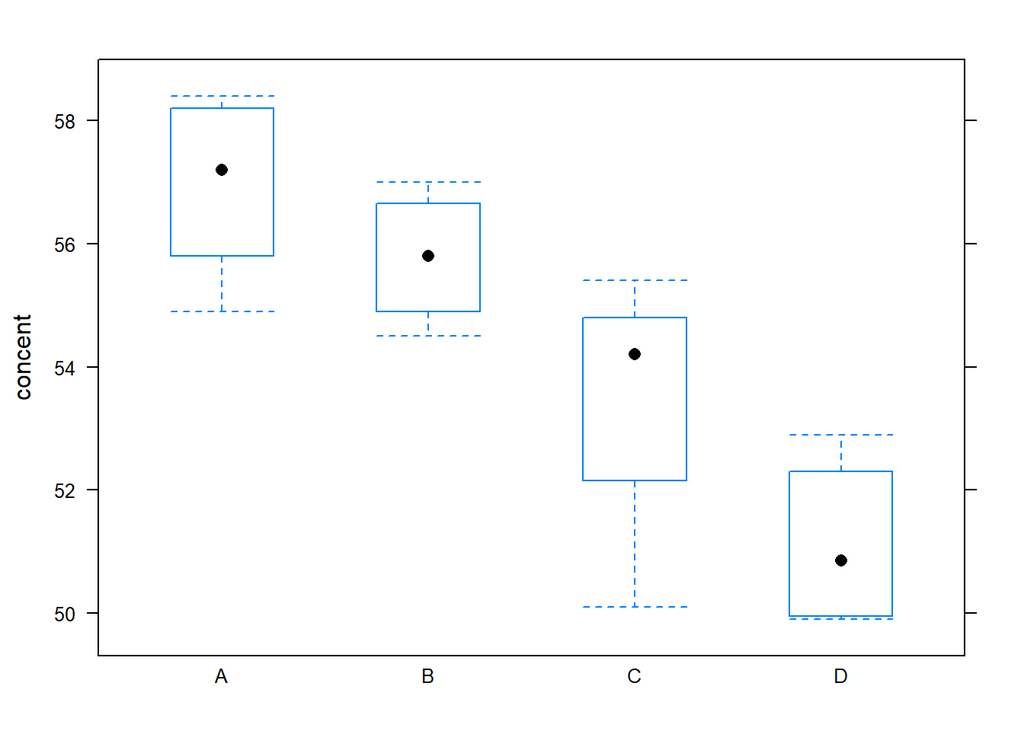

```r
bwplot(concent~catalyst,data=catalystm)
```

집단별로 그려진 boxplot에 따라 box의 형태를 변경할 수도 있다.  
`bwplot`의 `par.settingsg`옵션을 이용하여 box의 형태를 직접 지정할 수 있다. - box.umbrella: 최대값, 최소값에 대한 옵션을 결정한다.  
- box.dot: 중앙값에 대한 옵션을 결정한다.  
- box.retangle: 1사분위수, 3사분위수와 데이터의 분포의 정보를 가지고 있는 사각형에 대한 옵션을 결정한다.

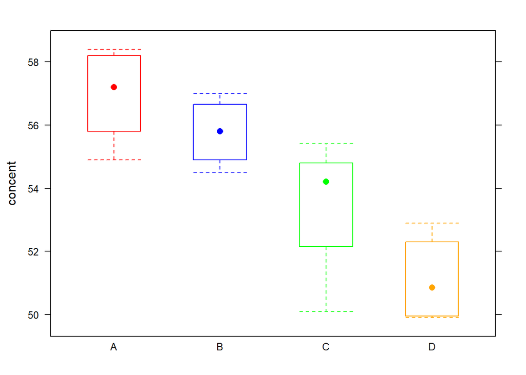

```r
bwplot(concent~catalyst,data=catalystm,par.settings=list(box.umbrella=list(col=c("red","blue","green","orange")),
                                                         box.dot=list(col=c("red","blue","green","orange")),
                                                         box.rectangle=list(col=c("red","blue","green","orange"))))
```

분산분석을 통해 우리는 집단간 차이가 있는지 없는지를 확인할 수 있다.  
만약, 모든 집단의 평균은 같다. 라는 귀무가설을 기각하게 되면, 적어도 한 집단에서 차이가 있다는 것을 알 수 있다.  
그렇다면, 이러한 차이가 있는 집단을 확인하고 싶을 것이다.  
이렇게 집단간에 차이가 어디에서 생겼는지 알고싶을 때 사용하는 것이 바로 사후검정 또는 다중비교(multiple comparison)이다.

R에서는 `mmc`함수를 통해 분산분석의 결과를 저장한 객체의 다중비교를 s진행할 수 있다.

mmc함수를 실행하게 되면 아래와 같은 결과를 얻을 수 있다.

```r
catalystm.mmc <-
  mmc(catalystmi.aov,linfct=mcp(catalyst="Tukey"))
catalystm.mmc
```

```
## Tukey contrasts
## Fit: aov(formula = concent ~ catalyst, data = catalystm)
## Estimated Quantile = 2.969086
## 95% family-wise confidence level
## $mca
##     estimate   stderr       lower    upper   height
## A-B 1.125000 1.138447 -2.25514805 4.505148 56.33750
## A-C 3.666667 1.239385 -0.01317243 7.346506 55.06667
## B-C 2.541667 1.296179 -1.30680118 6.390135 54.50417
## A-D 5.775000 1.138447  2.39485195 9.155148 54.01250
## B-D 4.650000 1.200029  1.08701111 8.212989 53.45000
## C-D 2.108333 1.296179 -1.74013452 5.956801 52.17917
## $none
##   estimate    stderr    lower    upper   height
## A 56.90000 0.7589649 54.64657 59.15343 56.90000
## B 55.77500 0.8485486 53.25559 58.29441 55.77500
## C 53.23333 0.9798195 50.32417 56.14250 53.23333
## D 51.12500 0.8485486 48.60559 53.64441 51.12500
```

집단간의 평균 차이 추정치, 표준오차, 평균차이의 하한과 상한 등 다양한 정보를 얻을 수 있다.

집단간의 차이에 대한 사후검정 뿐만아니라, 각 집단에 대한 평균, 표준오차, 평균 추정치의 하한과 상한에 대한 정보 또한 제공한다.

다중비교 역시 수치적으로 확인하는 것 보다는 시각적으로 한 눈에 살펴보는 것이 좋을 것이다.  
다중비교를 진행한 분석결과를 특정객체에 저장하고 R의 `mmcplot`을 이용하게 되면 다중비교의 결과를 한 눈에 살펴볼 수 있다.

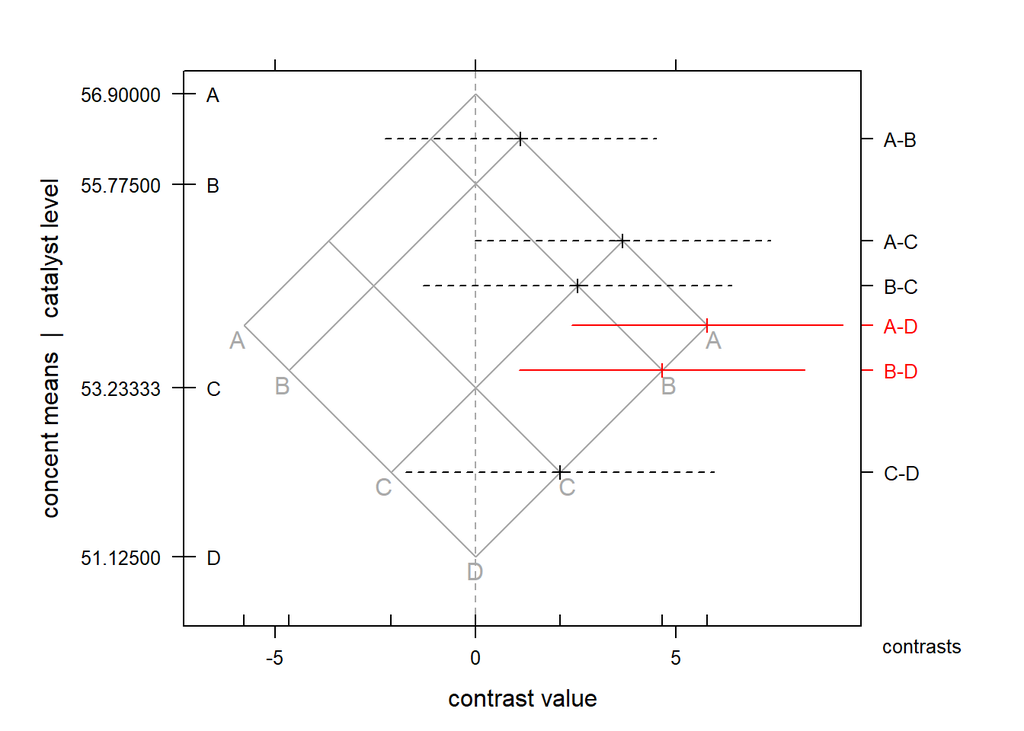

```r
mmcplot(catalystm.mmc)
```

mmcplot을 통해 다중비교의 결과를 시각적으로 나타내었다.  
각 집단의 평균의 값과 집단간 평균의 차이가 한 눈에 보이는 것을 확인할 수 있다.  
A-D, B-D의 집단간 차이의 신뢰구간이 0을 포함하지 않으므로 유의한 차이를 보이고 있는 집단이라고 할 수 있으며,  
집단간 차이가 유의하면 빨간색 실선, 유의하지 않으면 검은색 점선인 것을 확인할 수 있다.

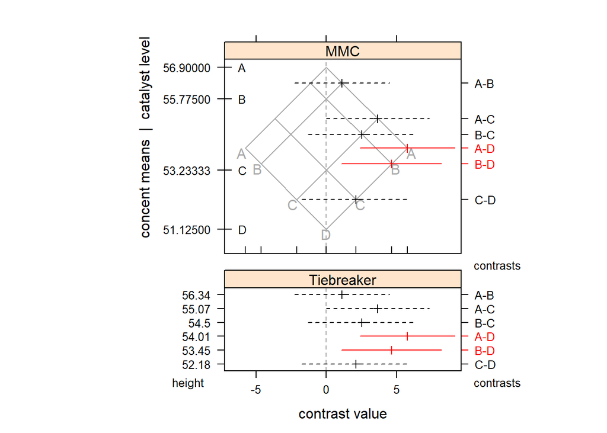

```r
mmcplot(catalystm.mmc,style="both")
```

`mmcplot`에서 `style = 'both'`라는 옵션을 지정하게 되면 기존에 MMCplot과 더불어 Tiebreaker라는 그림을 그릴 수 있다.  
Tiebreaker의 경우, 집단 별 차이만을 그림에 나타내며, 두 집단의 평균값 또한 나타내준다.  
MMCplot과 더불어 유의한 집단간 차이를 보이면 빨간색 실선으로 표시한다.

## 6.7 Example-Batch Data

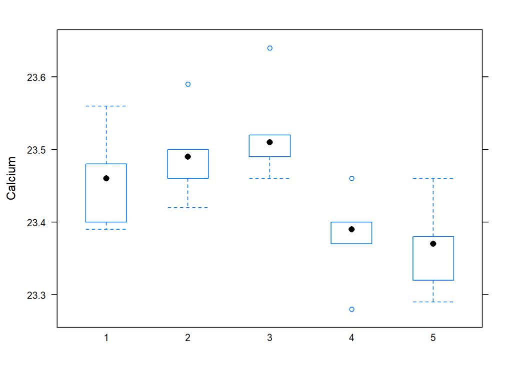

```r
data(batch)

bwplot(Calcium~Batch,data=batch)
```

```r
batch1.aov <- aov(Calcium~Batch,data=batch)
anova(batch1.aov)
```

```
## Analysis of Variance Table
##
## Response: Calcium
##           Df   Sum Sq  Mean Sq F value   Pr(>F)
## Batch      4 0.096976 0.024244  5.5352 0.003626 **
## Residuals 20 0.087600 0.004380
## ---
## Signif. codes:  0 '***' 0.001 '**' 0.01 '*' 0.05 '.' 0.1 ' ' 1
```

batch 데이터에 대한 분산분석을 진행한 결과 P-value는 0.003626으로 유의수준 0.05보다 작으므로, 적어도 하나의 집단에서 평균의 차이가 있다는 것을 알 수 있다.

분산분석의 기본 가정 중 하나는 등분산성을 만족하는 것이다. 여기서, 등분산이란 그룹간의 분산이 서로 같다는 것을 의미한다.  
등분산 검정의 귀무가설과 대립가설은 다음과 같다.  
H0: 모든 분산이 동일하다. (등분산성을 만족한다.) H1: 모든 분산이 동일하지않다. (등분산성을 만족하지 않는다.)

```r
hovBF(Calcium~Batch,data=batch)
```

```
##
##  hov: Brown-Forsyth
##
## data:  Calcium
## F = 0.032193, df:Batch = 4, df:Residuals = 20, p-value = 0.9978
## alternative hypothesis: variances are not identical
```

batch 데이터에 대한 등분산 검정을 진행한결과, P-value는 0.9978 유의수준 0.05보다 매우 큰 값을 가지는 것을 볼 수 있다.  
따라서, 귀무가설을 기각하지 못하므로 분산의 차이가 없다는 것을 알 수 있으며, 이를 통해, 등분산성을 만족하는 것을 알 수 있다.

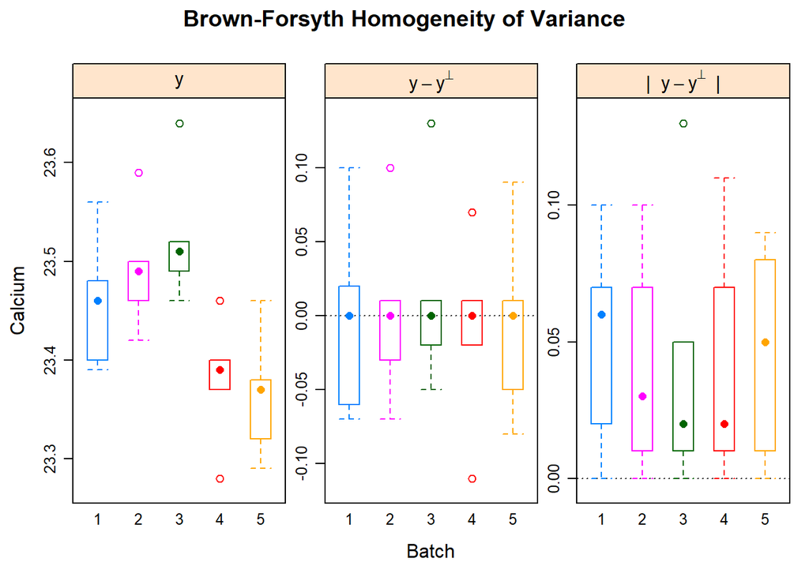

```r
hovplotBF(Calcium~Batch,data=batch)
```

hovplotBF 함수를 통해 등분상성에 대한 정보를 시각적으로 표현할 수 있다.  
왼쪽 패널의 경우, 집단간 데이터에 대한 boxplot을 보여주고,  
중앙 패널의 경우, 집단간 데이터와 데이터의 중앙값의 편차를 boxplot으로 나타내며,  
오른쪽 패널의 경우, 중앙 패널에 절대값을 씌운 boxplot을 나타낸다.

## 6.8.2 Data Description

```r
data(turkey)
turkey.aov <- aov(wt.gain ~ diet, data=turkey)
summary(turkey.aov)
```

[output not shown]

turkey 데이터에 대한 분산분석(ANOVA)를 진행한다.  
P-value는 5.6e-14로 거의 0에 가까운 값을 가지며, 유의수준 0.05보다 작으므로 귀무가설을 기각한다.  
즉, turkey 데이터의 diet 집단에 따라 차이 비교를 했을때, 적어도 한 집단 간 평균 차이가 존재한다고 할 수 있다.

```r
model.tables(turkey.aov,type="means",se=TRUE)
```

```
## Tables of means
## Grand mean
##
## 6.53
##
##  diet
## diet
## control      A1      A2      B1      B2
##   3.783   5.500   6.983   7.000   9.383
##
## Standard errors for differences of means
##           diet
##         0.3242
## replic.      6
```

`se=TRUE` 옵션을 지정하게 되면 평균의 차이에 대한 표준오차 값까지 얻을 수 있다.

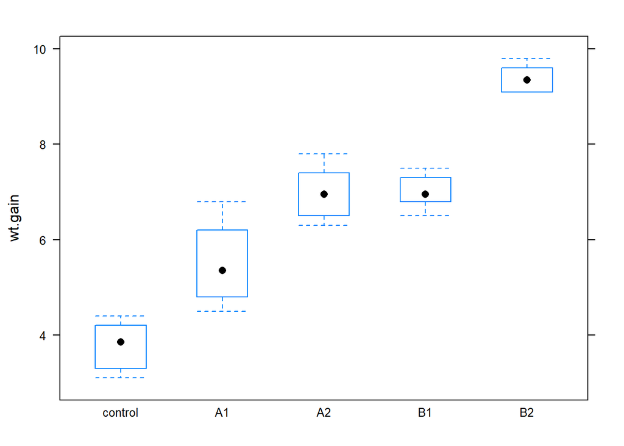

```r
bwplot(wt.gain~diet,data=turkey)
```

R에서는 범주형 변수들에 대해서 더미변수를 어떻게 인코딩하는지 확인할 수 있는데, 이러한 경우 `contrasts`함수를 이용한다.

## 6.8.4 Interpretation

```r
contrasts(turkey$diet)
```

```
##         A1 A2 B1 B2
## control  0  0  0  0
## A1       1  0  0  0
## A2       0  1  0  0
## B1       0  0  1  0
## B2       0  0  0  1
```

단순히 R에서 자동으로 인코딩 된 더미변수를 이용하는 것이 아니라, 연구자가 직접 설정할수도 있다.

```r
contrasts(turkey$diet)<-
  cbind(control.vs.treatment=c(1,-.25,-.25,-.25,-.25),
        A.vs.B = c(0,.5,.5,-.5,-.5),
        amount = c(0,.5,-.5,.5,-.5),
        A.vs.B.by.amount = c(0,.5,-.5,-.5,5))
contrasts(turkey$diet)
```

```
##         control.vs.treatment A.vs.B amount A.vs.B.by.amount
## control                 1.00    0.0    0.0              0.0
## A1                     -0.25    0.5    0.5              0.5
## A2                     -0.25    0.5   -0.5             -0.5
## B1                     -0.25   -0.5    0.5             -0.5
## B2                     -0.25   -0.5   -0.5              5.0
```

```r
library(dplyr)
tapply(turkey$wt.gain,turkey$diet,mean) %*%
  contrasts(turkey$diet)
```

```
##      control.vs.treatment A.vs.B    amount A.vs.B.by.amount
## [1,]            -3.433333  -1.95 -1.933333           42.675
```

```r
turkey2.aov <- aov(wt.gain~diet,data=turkey)
summary(turkey2.aov)
```

```
##             Df Sum Sq Mean Sq F value  Pr(>F)
## diet         4 103.04  25.759   81.67 5.6e-14 ***
## Residuals   25   7.88   0.315
## ---
## Signif. codes:  0 '***' 0.001 '**' 0.01 '*' 0.05 '.' 0.1 ' ' 1
```

앞서 설정한 contrasts(대비)에 대한 검정또한 진행할 수 있다.  
split을 통해 보고자 하는 대비 검정을 지정해준다.

```r
old.width <- options(width=67)

summary(turkey2.aov,
        split=list(diet=list(
          control.vs.treatment=1,
          A.vs.B=2,
          amount=3,
          A.vs.B.by.amount=4
        )))
```

```
##                              Df Sum Sq Mean Sq F value   Pr(>F)
## diet                          4 103.04   25.76  81.672 5.60e-14
##   diet: control.vs.treatment  1  56.58   56.58 179.395 6.58e-13
##   diet: A.vs.B                1  22.81   22.81  72.337 7.56e-09
##   diet: amount                1  22.43   22.43  71.105 8.88e-09
##   diet: A.vs.B.by.amount      1   1.21    1.21   3.852   0.0609
## Residuals                    25   7.88    0.32
##
## diet                         ***
##   diet: control.vs.treatment ***
##   diet: A.vs.B               ***
##   diet: amount               ***
##   diet: A.vs.B.by.amount     .
## Residuals
## ---
## Signif. codes:  0 '***' 0.001 '**' 0.01 '*' 0.05 '.' 0.1 ' ' 1
```

## 6.A Appendix: Computation for the Analysis of Variance

```r
data(catalystm)
catalystm.aov <- aov(concent ~ catalyst,
                     data=catalystm)
anova(catalystm.aov)
```

```
## Analysis of Variance Table
##
## Response: concent
##           Df Sum Sq Mean Sq F value   Pr(>F)
## catalyst   3 85.676 28.5586  9.9157 0.001436 **
## Residuals 12 34.562  2.8801
## ---
## Signif. codes:  0 '***' 0.001 '**' 0.01 '*' 0.05 '.' 0.1 ' ' 1
```

```r
model.tables(catalystm.aov)
```

```
## Tables of effects
##
##  catalyst
##         A     B      C      D
##     2.412 1.287 -1.254 -3.362
## rep 5.000 4.000  3.000  4.000
```

```r
Proj <- proj(catalystm.aov)
Proj <- cbind(Proj,Sum=apply(Proj,1,sum))
Proj
```

```
##    (Intercept)  catalyst  Residuals  Sum
## 1      54.4875  2.412500  1.3000000 58.2
## 2      54.4875  2.412500  0.3000000 57.2
## 3      54.4875  2.412500  1.5000000 58.4
## 4      54.4875  2.412500 -1.1000000 55.8
## 5      54.4875  2.412500 -2.0000000 54.9
## 6      54.4875  1.287500  0.5250000 56.3
## 7      54.4875  1.287500 -1.2750000 54.5
## 8      54.4875  1.287500  1.2250000 57.0
## 9      54.4875  1.287500 -0.4750000 55.3
## 10     54.4875 -1.254167 -3.1333333 50.1
## 11     54.4875 -1.254167  0.9666667 54.2
## 12     54.4875 -1.254167  2.1666667 55.4
## 13     54.4875 -3.362500  1.7750000 52.9
## 14     54.4875 -3.362500 -1.2250000 49.9
## 15     54.4875 -3.362500 -1.1250000 50.0
## 16     54.4875 -3.362500  0.5750000 51.7
```

```r
apply(Proj,2,function(x) sum(x^2))
```

```
## (Intercept)    catalyst   Residuals         Sum
## 47502.20250    85.67583    34.56167 47622.44000
```

```r
contrasts(catalystm$catalyst)
```

```
##   B C D
## A 0 0 0
## B 1 0 0
## C 0 1 0
## D 0 0 1
```

```r
X <- model.matrix(catalystm.aov)[,2:4]
X
```

```
##    catalystB catalystC catalystD
## 1          0         0         0
## 2          0         0         0
## 3          0         0         0
## 4          0         0         0
## 5          0         0         0
## 6          1         0         0
## 7          1         0         0
## 8          1         0         0
## 9          1         0         0
## 10         0         1         0
## 11         0         1         0
## 12         0         1         0
## 13         0         0         1
## 14         0         0         1
## 15         0         0         1
## 16         0         0         1
```

```r
catalystm.lm <-
  lm(concent ~ X[,"catalystB"]+X[,"catalystC"]+
       X[,"catalystD"],data=catalystm)

anova(catalystm.lm)
```

```
## Analysis of Variance Table
##
## Response: concent
##                  Df Sum Sq Mean Sq F value   Pr(>F)
## X[, "catalystB"]  1  8.841   8.841  3.0696 0.105259
## X[, "catalystC"]  1  2.722   2.722  0.9453 0.350118
## X[, "catalystD"]  1 74.112  74.112 25.7323 0.000274 ***
## Residuals        12 34.562   2.880
## ---
## Signif. codes:  0 '***' 0.001 '**' 0.01 '*' 0.05 '.' 0.1 ' ' 1
```

`par(mfrow=c())`함수를 이용해 subplot의 차원을 지정해 준 후, anova결과가 저장된 객체를 plot으로 나타낼 수 있다.

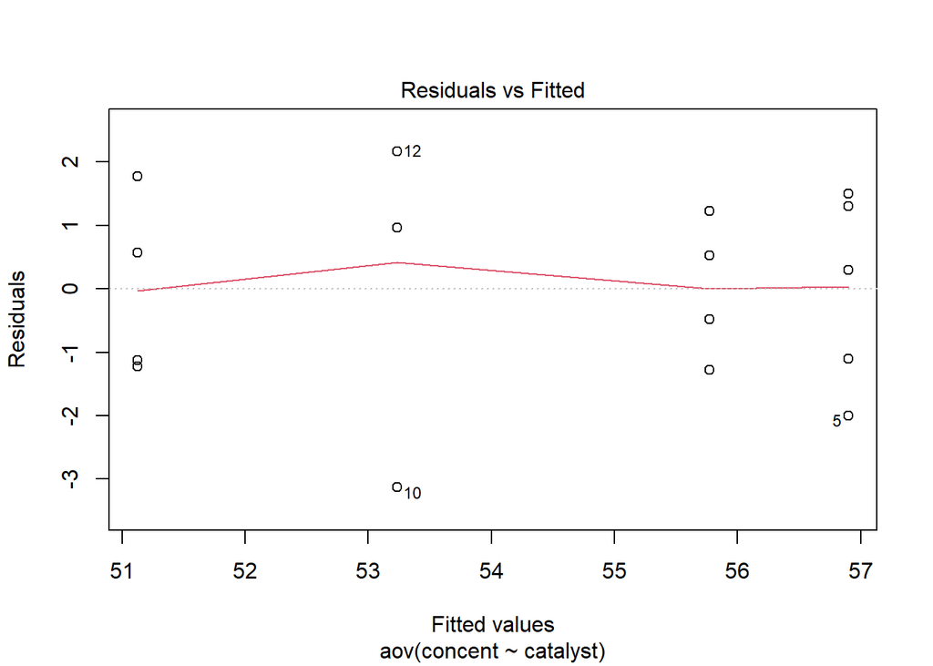

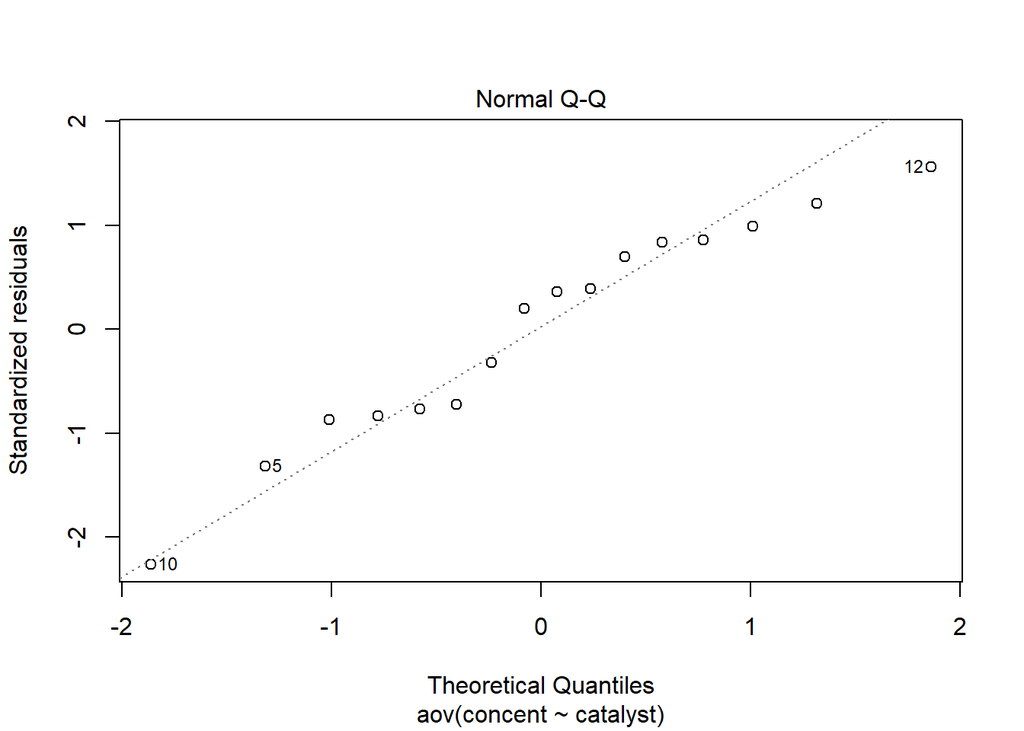

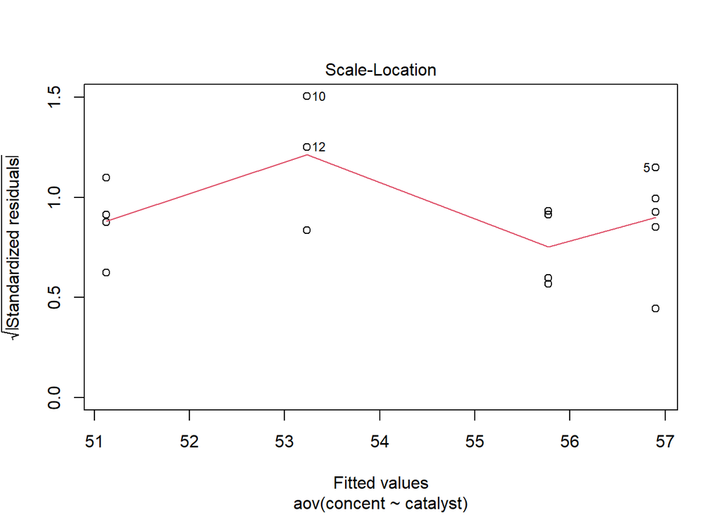

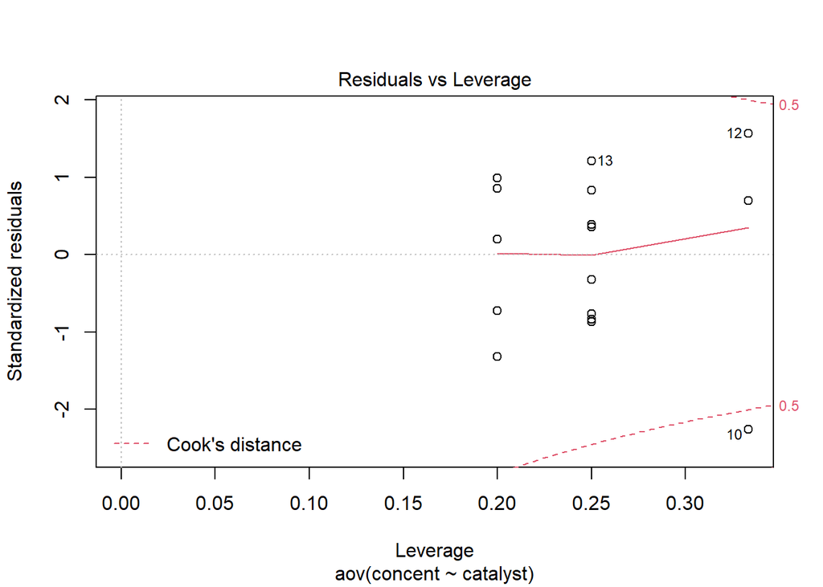

```r
old.par <- par(mfrow=c(1,4))
par(old.par)
plot(catalystm.aov)
```